# Assignment 2

Isabel

9/19/2019

First, load the `gapminder` and `tidyverse` packages. The `dplyr` package will be loaded via the `tidyverse` package.

```r
suppressPackageStartupMessages(library(gapminder))
suppressPackageStartupMessages(library(tidyverse))
suppressPackageStartupMessages(library(DT))
```

## Exercise 1

Let’s first have an overview of the data:

```r
DT::datatable(as_tibble(gapminder))
```

|  | country | continent | year | lifeExp | pop | gdpPercap |
| --- | --- | --- | --- | --- | --- | --- |
| 1 | Afghanistan | Asia | 1952 | 28.801 | 8425333 | 779.4453145 |
| 2 | Afghanistan | Asia | 1957 | 30.332 | 9240934 | 820.8530296 |
| 3 | Afghanistan | Asia | 1962 | 31.997 | 10267083 | 853.10071 |
| 4 | Afghanistan | Asia | 1967 | 34.02 | 11537966 | 836.1971382 |
| 5 | Afghanistan | Asia | 1972 | 36.088 | 13079460 | 739.9811058 |
| 6 | Afghanistan | Asia | 1977 | 38.438 | 14880372 | 786.11336 |
| 7 | Afghanistan | Asia | 1982 | 39.854 | 12881816 | 978.0114388 |
| 8 | Afghanistan | Asia | 1987 | 40.822 | 13867957 | 852.3959448 |
| 9 | Afghanistan | Asia | 1992 | 41.674 | 16317921 | 649.3413952 |
| 10 | Afghanistan | Asia | 1997 | 41.763 | 22227415 | 635.341351 |

[output cut: 1694 more lines]

Let’s now focus on the following three countries: Singapore, Malaysia and Indonesia:

```r
filtered<-gapminder%>%
  filter(year>1969 & year<1980)%>%
  filter(country %in% c('Singapore', 'Malaysia', 'Indonesia'))

DT::datatable(filtered)
```

|  | country | continent | year | lifeExp | pop | gdpPercap |
| --- | --- | --- | --- | --- | --- | --- |
| 1 | Indonesia | Asia | 1972 | 49.203 | 121282000 | 1111.107907 |
| 2 | Indonesia | Asia | 1977 | 52.702 | 136725000 | 1382.702056 |
| 3 | Malaysia | Asia | 1972 | 63.01 | 11441462 | 2849.09478 |
| 4 | Malaysia | Asia | 1977 | 65.256 | 12845381 | 3827.921571 |
| 5 | Singapore | Asia | 1972 | 69.521 | 2152400 | 8597.756202 |
| 6 | Singapore | Asia | 1977 | 70.795 | 2325300 | 11210.08948 |

We now only want the columns ‘country’ and ‘gdpPercap’ from the above dataset:

```r
filtered%>%
  select(country, gdpPercap)
```

| country | gdpPercap |
| --- | --- |
| Indonesia | 1111.108 |
| Indonesia | 1382.702 |
| Malaysia | 2849.095 |
| Malaysia | 3827.922 |
| Singapore | 8597.756 |
| Singapore | 11210.089 |

We want to see which countries have experienced a drop in life expectancy.

Here, in my code, I filter out the rows for year=1952 because these reflect the difference between *two* countries’ life expectancies. However, we only want to compare within-country differences.

From the data, we can see that the biggest drop in life expectancy occured in Rwanda between 1987 and 1992. On the converse, we can see that the biggest increase in life expectancy occured in Cambodia between 1977 and 1982. These results are not surprising, given that both countries experienced devastating genocides during those time periods.

```r
gapminder_mutated<-
  gapminder%>%
  mutate(difference=lifeExp-lag(lifeExp, 1))

gapminder_mutated%>%
  filter(difference<0)%>%
  filter(year!=1952)
```

| country | continent | year | lifeExp | pop | gdpPercap | difference |
| --- | --- | --- | --- | --- | --- | --- |
| Albania | Europe | 1992 | 71.58100 | 3326498 | 2497.4379 | -0.4190 |
| Angola | Africa | 1987 | 39.90600 | 7874230 | 2430.2083 | -0.0360 |
| Benin | Africa | 2002 | 54.40600 | 7026113 | 1372.8779 | -0.3710 |
| Botswana | Africa | 1992 | 62.74500 | 1342614 | 7954.1116 | -0.8770 |
| Botswana | Africa | 1997 | 52.55600 | 1536536 | 8647.1423 | -10.1890 |
| Botswana | Africa | 2002 | 46.63400 | 1630347 | 11003.6051 | -5.9220 |
| Bulgaria | Europe | 1977 | 70.81000 | 8797022 | 7612.2404 | -0.0900 |
| Bulgaria | Europe | 1992 | 71.19000 | 8658506 | 6302.6234 | -0.1500 |
| Bulgaria | Europe | 1997 | 70.32000 | 8066057 | 5970.3888 | -0.8700 |
| Burundi | Africa | 1992 | 44.73600 | 5809236 | 631.6999 | -3.4750 |

[output cut: 92 more lines]

```r
gapminder_mutated%>%
    filter(year!=1952)%>%
  filter(difference==min(difference))
```

| country | continent | year | lifeExp | pop | gdpPercap | difference |
| --- | --- | --- | --- | --- | --- | --- |
| Rwanda | Africa | 1992 | 23.599 | 7290203 | 737.0686 | -20.421 |

```r
gapminder_mutated%>%
    filter(year!=1952)%>%
  filter(difference==max(difference))
```

| country | continent | year | lifeExp | pop | gdpPercap | difference |
| --- | --- | --- | --- | --- | --- | --- |
| Cambodia | Asia | 1982 | 50.957 | 7272485 | 624.4755 | 19.737 |

The following shows the maximum GDP per capita experienced by each country:

```r
gapminder%>%
  group_by(country)%>%
  filter(gdpPercap==max(gdpPercap))
```

| country | continent | year | lifeExp | pop | gdpPercap |
| --- | --- | --- | --- | --- | --- |
| Afghanistan | Asia | 1982 | 39.854 | 12881816 | 978.0114 |
| Albania | Europe | 2007 | 76.423 | 3600523 | 5937.0295 |
| Algeria | Africa | 2007 | 72.301 | 33333216 | 6223.3675 |
| Angola | Africa | 1967 | 35.985 | 5247469 | 5522.7764 |
| Argentina | Americas | 2007 | 75.320 | 40301927 | 12779.3796 |
| Australia | Oceania | 2007 | 81.235 | 20434176 | 34435.3674 |
| Austria | Europe | 2007 | 79.829 | 8199783 | 36126.4927 |
| Bahrain | Asia | 2007 | 75.635 | 708573 | 29796.0483 |
| Bangladesh | Asia | 2007 | 64.062 | 150448339 | 1391.2538 |
| Belgium | Europe | 2007 | 79.441 | 10392226 | 33692.6051 |

[output cut: 132 more lines]

Here is a scatterplot showing Canada’s life expectancy versus GDP per capita (logged):

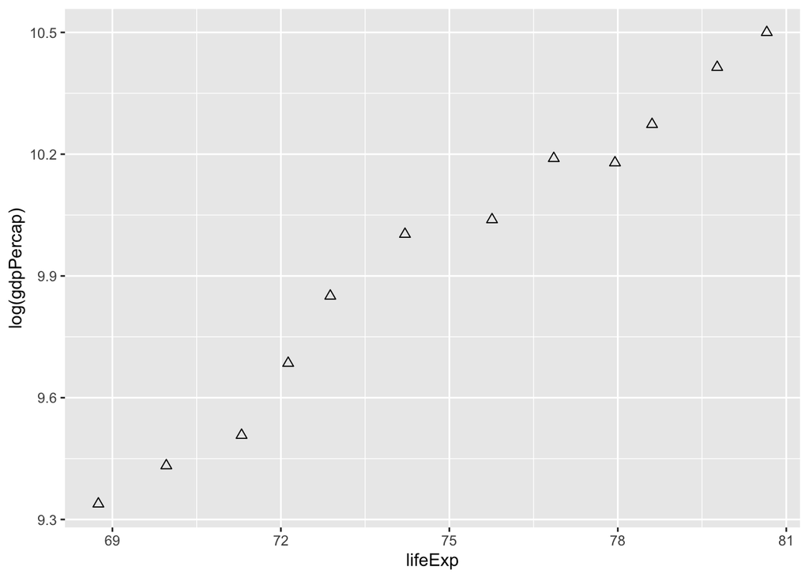

```r
gapminder%>%
  filter(country=="Canada")%>%
  ggplot(aes(lifeExp, log(gdpPercap)))+
  geom_point(size=2, shape=2)
```

## Exercise 2

### Exploring countries

There are 142 distinct countries represented in the gapminder dataset.

```r
gapminder%>%
  distinct(country)
```

| country |
| --- |
| Afghanistan |
| Albania |
| Algeria |
| Angola |
| Argentina |
| Australia |
| Austria |
| Bahrain |
| Bangladesh |
| Belgium |

[output cut: 132 more lines]

We can randomly select 10 distinct countries to have a feel of the possible values.

```r
gapminder%>%
  sample_n(10)%>%
  distinct()%>%
  select(country)
```

| country |
| --- |
| Kenya |
| Nepal |
| United States |
| Trinidad and Tobago |
| West Bank and Gaza |
| China |
| Belgium |
| Nigeria |
| Cote d'Ivoire |
| Egypt |

We can find out how many countries there are in each continent, with Africa having the highest number of distinct countries (52) and Oceania having the least number of distinct countries (2).

```r
gapminder%>%
  group_by(continent)%>%
  mutate(no_of_countries=n()/12)%>%
  select(continent, no_of_countries)%>%
  distinct()
```

| continent | no_of_countries |
| --- | --- |
| Asia | 33 |
| Europe | 30 |
| Africa | 52 |
| Americas | 25 |
| Oceania | 2 |

### Exploring life expectancy

We can obtain summary statistics for life expectancy, including the mininum value, 1st quartile, median, mean, 3rd quantile and maximum value.

The *range* for life expectancy is (23.60, 82.60), and its *IQR* is 22.65.

The *mean* life expectancy is 59.47 and the *median* life expectancy is 60.71.

```r
gapminder%>%
  select(lifeExp)%>%
  summary()
```

```
##     lifeExp
##  Min.   :23.60
##  1st Qu.:48.20
##  Median :60.71
##  Mean   :59.47
##  3rd Qu.:70.85
##  Max.   :82.60
```

The country with the lowest life expectancy is Rwanda in 1992 and the country with the highest is Japan in 2007.

```r
gapminder%>%
  filter(lifeExp==min(lifeExp))%>%
  select(country, year)
```

| country | year |
| --- | --- |
| Rwanda | 1992 |

```r
gapminder%>%
  filter(lifeExp==max(lifeExp))%>%
  select(country, year)
```

| country | year |
| --- | --- |
| Japan | 2007 |

We can also look at which continents have the highest and lowest average life expectancies in the world. Africa has the lowest average life expectancy at 49 years, while Oceania had the highest average life expectancy at 74 years.

```r
gapminder%>%
  group_by(continent)%>%
  summarise(mean(lifeExp))
```

| continent | mean(lifeExp) |
| --- | --- |
| Africa | 48.86533 |
| Americas | 64.65874 |
| Asia | 60.06490 |
| Europe | 71.90369 |
| Oceania | 74.32621 |

## Exercise 3

Let’s look at a time series of GDP across time for Singapore. We can notice a positive trend in which GDP is increasing across time.

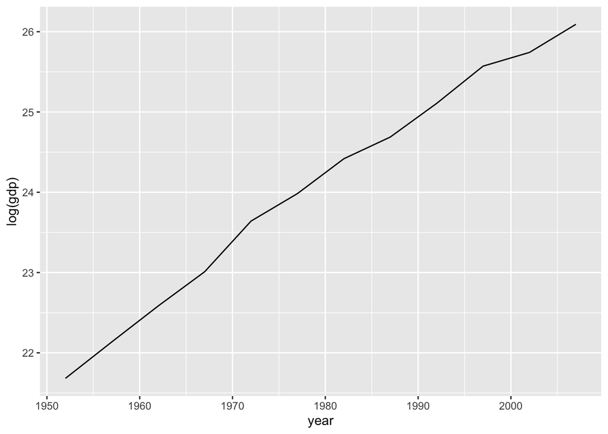

```r
gapminder%>%
  mutate(gdp=gdpPercap*pop)%>%
  filter(country=="Singapore")%>%
  ggplot(aes(year, log(gdp)))+
  geom_line()
```

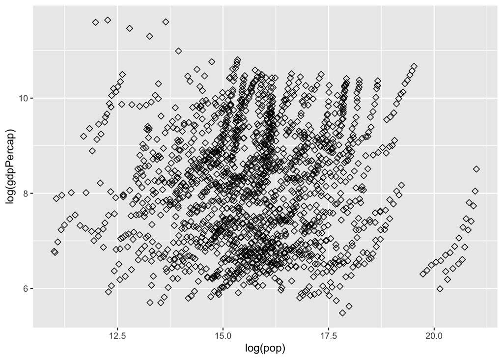

```r
gapminder%>%
  ggplot(aes(log(pop), log(gdpPercap)))+
  geom_point(size=2, shape=23)
```

Let’s now look at the average GDP per capita for each continent.The boxplots have been arranged in order of increasing magnitude to better reflect the differences between continents. Again, we can see that despite having the most number of countries, Africa has the lowest median GDP per capita. On the other hand, despite having the least number of countries, Oceania has the highest median GDP per capita.

It would be good to label the outliers in the boxplots as well, and in the subsequent weeks, I hope I can figure out how to do that.

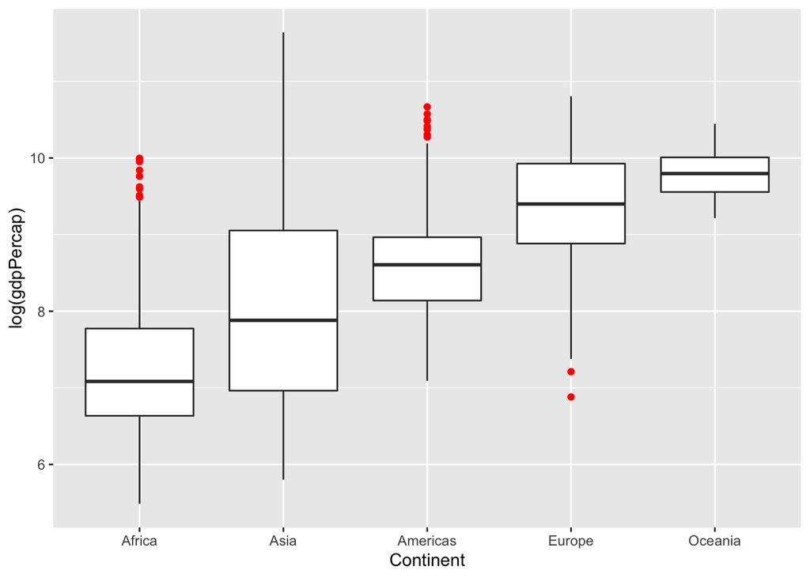

```r
gapminder%>%
  ggplot(aes(x=reorder(continent, log(gdpPercap), FUN=median), log(gdpPercap)))+
  geom_boxplot(outlier.colour="red")+
  xlab("Continent")
```